# R Notebook

# Question 1

Load in the libraries you need, and look at the backpack data. Take note of variable names and dimensions.

```r
library(tidyverse)
library(CodeClanData)
backpack
```

| backpack_weight | body_weight | ratio | back_problems | major | year | sex | status | units |
| --- | --- | --- | --- | --- | --- | --- | --- | --- |
| 9 | 125 | 0.0720000 | 1 | Bio | 3 | Female | U | 13 |
| 8 | 195 | 0.0410256 | 0 | Philosophy | 5 | Male | U | 12 |
| 10 | 120 | 0.0833333 | 1 | GRC | 4 | Female | U | 14 |
| 6 | 155 | 0.0387097 | 0 | CSC | 6 | Male | G | 0 |
| 8 | 180 | 0.0444444 | 0 | EE | 2 | Female | U | 14 |
| 5 | 240 | 0.0208333 | 0 | History | 0 | Male | G | 0 |
| 8 | 170 | 0.0470588 | 0 | CM | 3 | Male | U | 15 |
| 4 | 185 | 0.0216216 | 1 | ARCE | 5 | Female | U | 18 |
| 5 | 130 | 0.0384615 | 0 | Bio | 4 | Female | U | 14 |
| 2 | 120 | 0.0166667 | 0 | Bio | 5 | Female | U | 8 |

[output cut: 90 more lines]

```r
NA
```

# Question 2

What is the distribution of backpack weights that students are carrying? Choose an appropriate graph to show the distribution.

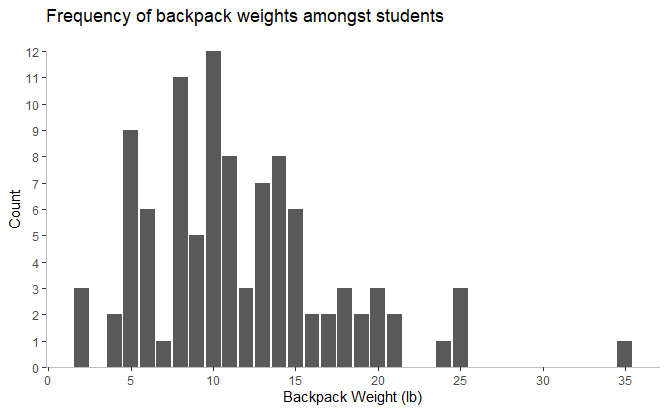

```r
backpack %>%
  ggplot(aes(backpack_weight)) +
  geom_bar() +
  labs(x = "Backpack Weight (lb)",
       y = "Count",
       title = "Frequency of backpack weights amongst students\n") +
  scale_y_continuous(labels = scales::label_number(accuracy = 1, scale = 1),
                     breaks = seq(0, 12), #12 is manually entered here, ideally this would be calculated.
                     expand = c(0, 0)) +
  scale_x_continuous(breaks = seq(0, max(backpack$backpack_weight), by = 5)) +
  theme(panel.background = element_rect(fill = "white"),
        axis.line = element_line(colour = "gray"))
```

The frequency plot (histogram) of backpack weights amongst students shows a relatively normal distribution with the majority of weights between 4 and 21lbs. There are however outliers in the dataset with a maximum weight of 35lbs.

# Question 3

Are there differences in backpack weight between sex?

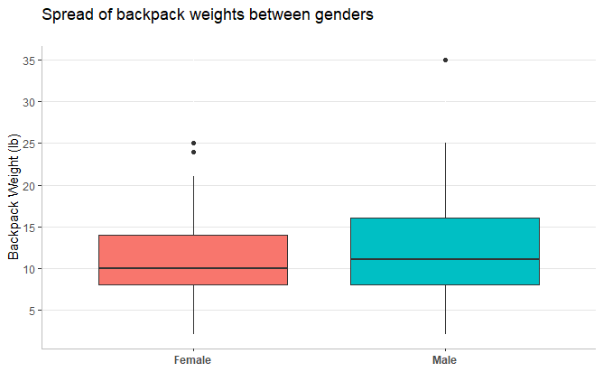

```r
backpack %>%
  ggplot(aes(x = backpack_weight,
             y = sex,
             fill = sex)) +
  geom_boxplot(show.legend = FALSE) +
  labs(x = "Backpack Weight (lb)",
       title = "Spread of backpack weights between genders\n") +
  scale_x_continuous(breaks = seq(5, 35, 5)) +
  theme(panel.background = element_rect(fill = "white"),
        axis.line = element_line(colour = "gray"),
        axis.title.x = element_blank(),
        axis.text.x = element_text(face = "bold"),
        panel.grid.major.y = element_line(colour = "gray90")) +
  coord_flip()
```

# Question 4.

What is the relationship between body weight and backpack weight?

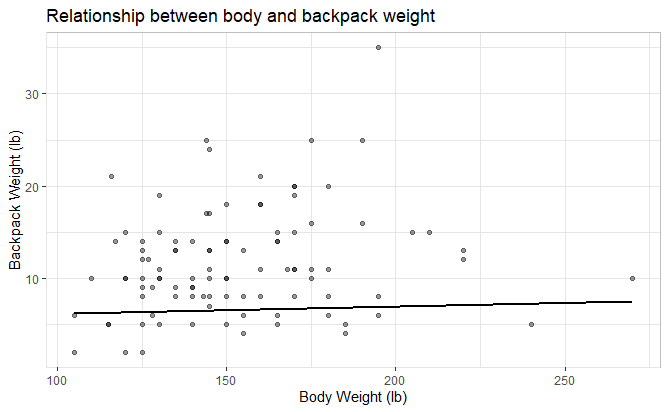

```r
backpack %>%
  ggplot(aes(x = body_weight,
             y = backpack_weight)) +
  geom_point(alpha = 0.4) +
  labs(x = "Body Weight (lb)",
       y = "Backpack Weight (lb)",
       title = "Relationship between body and backpack weight") +
  theme(panel.background = element_rect(fill = "white"),
        panel.border = element_rect(colour = "gray", fill = NA),
        axis.line = element_line(colour = "gray90"),
        panel.grid = element_line(colour = "gray90")) +
  geom_smooth(n = 2, se = F, colour = "black")
```

The scatterplot above shows that there appears to be somewhat of a positive correlation towards the centre of the data where higher backpack weights are observed with persons of higher body weight. This, in principal, would make sense since heavier people are likely to be stronger and can carry heavier backpacks and vice versa for lighter people. However, across the entire dataset this relationship falls apart due to the outliers. The line of best fit shows that there is no correlation between the two parameters.

# Question 5.

Is this relationship different between men and women? Choose an appropriate plot and interpret your findings.

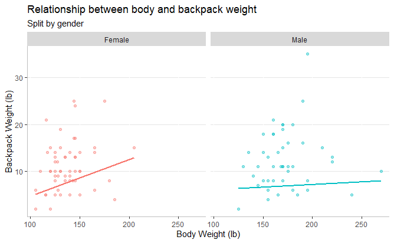

```r
backpack %>%
  ggplot(aes(x = body_weight,
             y = backpack_weight,
             group = sex,
             colour = sex)) +
  geom_point(show.legend = F, alpha = 0.4) +
  labs(x = "Body Weight (lb)",
       y = "Backpack Weight (lb)",
       title = "Relationship between body and backpack weight",
       subtitle = "Split by gender") +
  theme(panel.background = element_rect(fill = "white"),
        axis.line = element_line(colour = "gray"),
        panel.grid.major.y = element_line(colour = "gray90")) +
  facet_wrap(~ sex, ncol = 2) +
  geom_smooth(n = 2, se = F, show.legend = F)
```

Splitting the data between Male and Female shows that there is a small positive relationship between body and backpack weight, this is different from the analysis done previously which indicated no correlation. For males, there is still no correlation between the parameters.

# Question 6.

What proportion of students report back pain?

```r
backpack %>%
  group_by(back_problems) %>%
  summarise(count = n())
```

| back_problems | count |
| --- | --- |
| 0 | 68 |
| 1 | 32 |

```r
NA
```

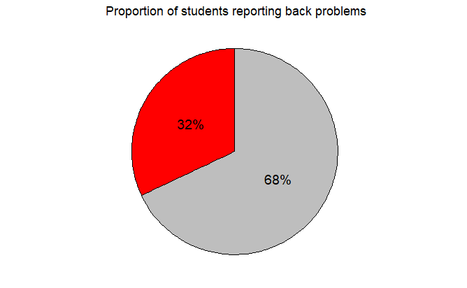

```r
backpack %>%
  group_by(back_problems) %>%
  summarise(percent = n()/nrow(backpack)) %>%
  ggplot(aes(x = "", y = percent, label = paste0(percent*100, "%"))) +
  geom_col(position = "fill",
           fill = c("gray","red"),
           colour = c("black")) +
  coord_polar(theta = "y") +
  geom_text(size = 5, position = position_fill(vjust = 0.5)) +
  labs(title = "Proportion of students reporting back problems",
       fill = "Back Problems") +
  theme(panel.background = element_rect(fill = "white"),
        axis.text = element_blank(),
        axis.title = element_blank(),
        panel.grid = element_blank(),
        axis.ticks = element_blank())
```

```r
NA
```

The pie chart above shows that 32% of students experience back problems.

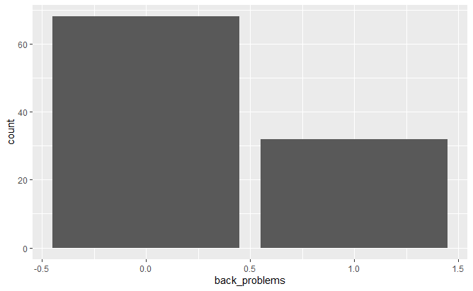

```r
backpack %>%
  ggplot(aes(back_problems)) +
  geom_bar()
```

```r
  # coord_polar(theta = "y") +
  # geom_text(size = 5, position = position_fill(vjust = 0.5)) +
  # labs(title = "Proportion of students reporting back problems",
  #      fill = "Back Problems") +
  # theme(panel.background = element_rect(fill = "white"),
  #       axis.text = element_blank(),
  #       axis.title = element_blank(),
  #       panel.grid = element_blank(),
  #       axis.ticks = element_blank())
```

# Question 7.

Is this proportion different between men and women?

```r
backpack %>%
  group_by(sex, back_problems) %>%
  summarise(count = n()) %>%
  group_by(sex) %>%
  summarise(count, sum = sum(count), percent = count/sum)
```

| sex | count | sum | percent |
| --- | --- | --- | --- |
| Female | 31 | 55 | 0.5636364 |
| Female | 24 | 55 | 0.4363636 |
| Male | 37 | 45 | 0.8222222 |
| Male | 8 | 45 | 0.1777778 |

```r
backpack %>%
  group_by(sex, back_problems) %>%
  summarise(count = n()) %>%
  group_by(sex) %>%
  summarise(count, sum = sum(count), frac = count/sum * 100)
```

| sex | count | sum | frac |
| --- | --- | --- | --- |
| Female | 31 | 55 | 56.36364 |
| Female | 24 | 55 | 43.63636 |
| Male | 37 | 45 | 82.22222 |
| Male | 8 | 45 | 17.77778 |

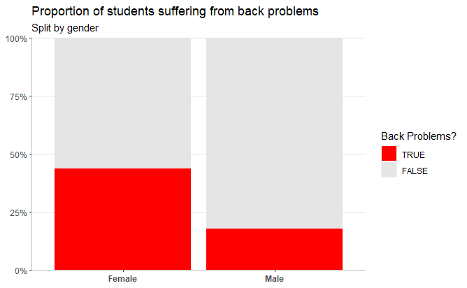

```r
backpack %>%
  mutate(back_problems = as.logical(back_problems)) %>%
  ggplot(aes(x = sex,
              group = back_problems,
              fill = back_problems,
             label = mean(body_weight))) +
  geom_bar(position = "fill") +
  scale_fill_manual(values = c("TRUE" = "red", "FALSE" = "gray90")) +
  scale_y_continuous(labels = scales::percent,
                     expand = c(0, 0)) +
  theme(panel.background = element_rect(fill = "white"),
        axis.line = element_line(colour = "gray"),
        panel.grid.major.y = element_line(colour = "gray90"),
        axis.title = element_blank(),
        axis.text.x = element_text(face = "bold")) +
  labs(title = "Proportion of students suffering from back problems",
       subtitle = "Split by gender",
       fill = "Back Problems?")
```

```r
NA
NA
```

The graph above shows that females experience a higher proportion of back problems (44%) vs males (18%).

[Unable to get the percentages on the graph so added in the y-axis to show proportion. Table above shows percentage values for each gender.]

# Question 8.

Now you’ve investigated your data separately, create plots to describe the relationship between backpack weight, body weight, gender and reported backpain.

Try both backpack_weight and body_weight as well as the ratio.

Hint: faceting would be useful here.

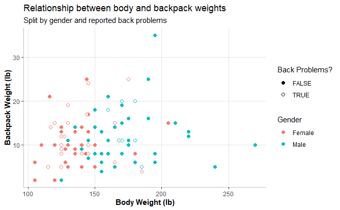

```r
backpack %>%
  mutate(back_problems = as.logical(back_problems)) %>%
  ggplot(aes(y = backpack_weight, x = body_weight, group = back_problems)) +
  geom_point(aes(colour = sex, shape = back_problems),
             size = 2,
             fill = "white") +
  scale_shape_manual(values = c(16, 21)) +
  # facet_grid(sex ~ back_problems, labeller = label_both) +
  labs(y = "Backpack Weight (lb)",
       x = "Body Weight (lb)",
       fill = "Gender",
       title = "Relationship between body and backpack weights",
       subtitle = "Split by gender and reported back problems",
       shape = "Back Problems?",
       colour = "Gender") +
  theme(panel.background = element_rect(fill = "white"),
        axis.line = element_line(colour = "gray"),
        panel.grid.major = element_line(colour = "gray90"),
        axis.title = element_text(face = "bold"),
        legend.key = element_blank())
```

The above plot consolidates all of the data related to body, backpack, gender and back problems into a single plot. The plot follows the same trend as in Q4 and Q5. The rate at which back problems occurs at different levels between males and females, females typically report back problems at lower backpack weights (bottom left of the plot), which is consistent with lower typical body weights too.

average ratio of back problems between males and females

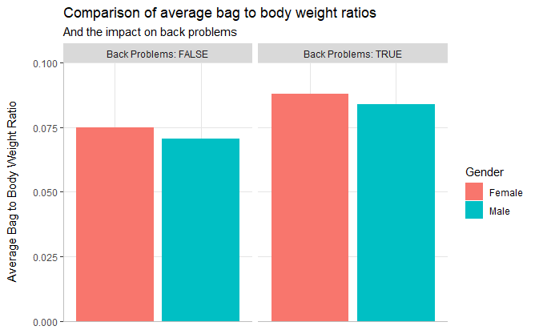

```r
backpack %>%
  mutate(back_problems = as.logical(back_problems)) %>%
  group_by(sex, back_problems) %>%
  summarise(avg_ratio = mean(ratio)) %>%
  ggplot(aes(x = sex, y = avg_ratio, fill = sex)) +
  geom_col() +
  facet_wrap(~ back_problems, labeller = labeller(back_problems = c("TRUE" = "Back Problems: TRUE", "FALSE" = "Back Problems: FALSE"))) +
  theme(panel.background = element_rect(fill = "white"),
        axis.line = element_line(colour = "gray"),
        panel.grid.major = element_line(colour = "gray90"),
        legend.key = element_blank(),
        axis.title.x = element_blank(),
        axis.text.x = element_blank(),
        axis.ticks.x = element_blank()) +
  labs(x = "Gender",
       y = "Average Bag to Body Weight Ratio\n",
       fill = "Gender",
       title = "Comparison of average bag to body weight ratios",
       subtitle = "And the impact on back problems") +
  scale_y_continuous(expand = c(0, 0),
                     limits = c(0, 0.1))
```

The bar chart above shows that back problems tend to occur at higher bag to body weight ratio. This makes sense that if a student is carrying a heavy bag (in relation to their body weight) then there is a higher risk of back problems.

For females, the bag to body weight ratio is higher in instances where back problems are reported than for males. The data suggests that females on average carry heavier bags (in relation to their body weight, i.e. ratio) than males do. This is because, on average, females are lighter than males and are quite likely to carry the same weight of bag.

# Question 1.

Does reported backpain differ across the year groups? Ignore year 0 in your data.

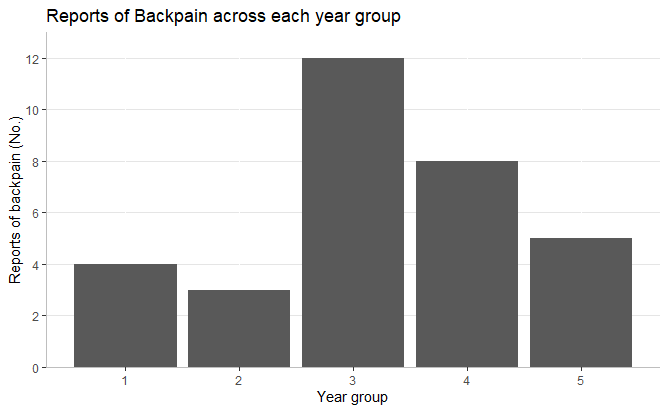

```r
backpack %>%
  filter(back_problems == 1) %>%
  ggplot(aes(x = year, y = back_problems)) +
  geom_col() +
  scale_y_continuous(expand = c(0,0),
                     limits = c(0,13),
                     breaks = scales::pretty_breaks()) +
  theme(panel.background = element_rect(fill = "white"),
        axis.line = element_line(colour = "gray"),
        panel.grid.major.y = element_line(colour = "gray90"),
        legend.key = element_blank()) +
  labs(x = "Year group",
       y = "Reports of backpain (No.)",
       title = "Reports of Backpain across each year group")
```

# Question 2.

Is there a difference between how heavy the bags those in different years carry?

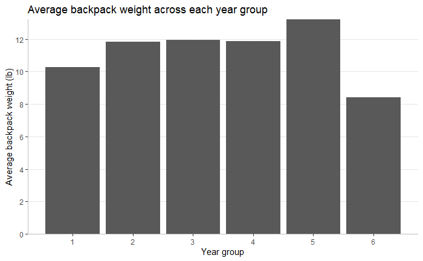

```r
backpack %>%
  filter(year != 0) %>%
  group_by(year) %>%
  summarise(avg_backpack_weight = mean(backpack_weight, na.rm = TRUE)) %>%
  ggplot(aes(x = year, y = avg_backpack_weight)) +
  geom_col(position = "dodge") +
  scale_y_continuous(expand = c(0,0),
                     breaks = scales::pretty_breaks()) +
  scale_x_continuous(breaks = 0:6) +
  theme(panel.background = element_rect(fill = "white"),
        axis.line = element_line(colour = "gray"),
        panel.grid.major.y = element_line(colour = "gray90"),
        legend.key = element_blank()) +
  labs(x = "Year group",
       y = "Average backpack weight (lb)",
       title = "Average backpack weight across each year group")
```

```r
NA
NA
```

The average backpack weight increases significantly from year groups 1 to 2 where it plateaus at Year group 2. Year groups 2 - 4 are very similar (approx. 12lb) with a further increase in Year Group 5 up to 13lb, before a significant drop down to around 8lb for Year Group 6. The data shows a good correlation with what might be expected, i.e. first year of college has the least amount of materials to be carried, years 2-4 are very similar and year 5 (final year) is the most demanding therefore needs the most materials (i.e. heavier backpack).